# **Môn học: TOÁN ỨNG DỤNG và THỐNG KÊ**

## **ĐỒ ÁN THỰC HÀNH CUỐI KỲ**

### Học kỳ 3, năm học 2023-2024; Lớp: **22CLC02-06**

### Câu 2: Markov Chain - Ngày 15/08/2024

# 1. Thông tin sinh viên

- Họ và tên: Nguyễn Gia Huy
- MSSV: 22127154
- Lớp: 22CLC06

# 2. Giới thiệu bài toán

Tòa nhà I của trường Đại học Khoa học Tự nhiên được xây dựng hoàn tất và đưa vào sử dụng từ năm 2000. Giả sử tòa nhà I có 50 phòng học và cơ sở vật chất (CSVC) của các phòng học này được quản lyus bởi Phòng Quản trị thiết bị (PQTTB). PQTTB sẽ khảo sát, thu thập các thông tin về hiện trạng CSVC của các phòng học để đánh giá chất lượng và từ đó lập kế hoạch bảo trì cho phù hợp. Giả sử công tác này được thực hiện hàng năm và hiện trạng CSVC của các phòng học được đánh giá theo 4 loại trạng thái chất lượng sau đây:

- Trạng thái 1: CSVC của phòng học có chất lượng tốt
- Trạng thái 2: CSVC của phòng học có chất lượng khá
- Trạng thái 3: CSVC của phòng học có chất lượng trung bình
- Trạng thái 4: CSVC của phòng học có chất lượng xấu

Giả sử PQTTB đã đánh giá xếp loại chất lượng phòng học trong 2 năm 2020 và 2021 và tổng hợp kết quả như sau:

| Trạng thái | Mô tả trạng thái | 2020 | 2021 |
| --- | --- | --- | --- |
| 1 | CSVC tốt | 34 | 26 |
| 2 | CSVC khá | 12 | 17 |
| 3 | CSVC trung bình | 3 | 5 |
| 4 | CSVC xấu | 1 | 2 |
| Tổng |  | 50 | 50 |

Biết rằng trong thời hạn 1 năm, sự xuống cấp về CSVC (thay đổi trạng thái) của các phòng học diễn ra không quá 1 cấp trong điều kiện PQTTB không thực hiện bất kỳ công tác bảo trì, sữa chữa nào. Khi đó, quá trình xuống cấp về CSVC của các phòng học thuộc tòa nhà I là một quá trình ngẫu nhiên có tính Markov. Giả sử năm 2021 là năm bắt đầu của xích Markov.

Yêu cầu:

- a. Từ bảng số liệu trên, xây dựng ma trận chuyển trạng thái P của xích Markov.
- b. Với các điều kiện của bài toán đã cho, xác định vector phân phối xác suất ban đầu $\pi_0$ của xích Markov.
- c. Hãy dự báo sự xuống cấp về CSVC của các phòng học tòa nhà I trong vòng 15 năm tới, kể từ năm 2021. Kết quả dự báo trình bày trong bảng sau:

| Năm | Trạng thái 1 | Trạng thái 2 | Trạng thái 3 | Trạng thái 4 |
| --- | --- | --- | --- | --- |
| 2021 |  |  |  |  |
| 2022 |  |  |  |  |
| 2023 |  |  |  |  |
| ... |  |  |  |  |
| 2033 |  |  |  |  |
| 2034 |  |  |  |  |
| 2035 |  |  |  |  |

- d. Xác định thời điểm (năm) phải phá hủy để xây lại/trùng tu tòa nhà I (tất cả phòng học đều ở trạng thái CSVC xấu)
- e. Xác định tuổi thọ của tòa nhà I

# 3. Ý tưởng thực hiện

Trong bài toán này, ta sẽ sử dụng xích Markov để mô hình hóa quá trình xuống cấp về CSVC của các phòng học thuộc tòa nhà I. Gọi $X_t$ là biến ngẫu nhiên mô tả trạng thái của CSVC của các phòng học vào năm thứ $t$. Ta có thể mô tả xích Markov này bằng ma trận chuyển trạng thái $P$ và vector phân phối xác suất ban đầu $\pi_0$. Tập trạng thái của xích Markov là $S = \{1, 2, 3, 4\}$ tương ứng với các trạng thái chất lượng CSVC của các phòng học.

## a. Xây dựng ma trận chuyển trạng thái $P$

Ma trận chuyển trạng thái $P$ là ma trận với $P_{ij}$ là xác suất chuyển từ một trạng thái $j$ sang một trạng thái $i$ trong một bước thời gian. Ta có thể xây dựng ma trận $P$ từ bảng số liệu cho trước như sau bằng 2 cách suy luận ngược và suy luận tiến:

- Suy luận ngược: Bắt đầu từ trạng thái $4$ (CSVC xấu), ta thấy năm 2020 có 1 phòng có trạng thái $4$, tuy nhiên đến năm $2021$ thì có 2 phòng. Suy ra đã có 1 phòng của năm 2020 chuyển từ trạng thái $3$ sang trạng thái $4$. Từ đó suy ra trong 3 phòng ở trạng thái $3$ của năm 2020, chỉ có 2 phòng giữ nguyên trang thái $3$ vào năm 2021, nhưng số lượng phòng ở trạng thái $3$ vào năm 2021 là 5, suy ra có 3 phòng năm 2020 chuyển từ trạng thái $2$ sang trạng thái $3$. Tương tự, ta suy luận ra các buớc chuyển trạng thái khác.
- SUy luận tiến: Bắt đầu từ trạng thái $1$ (CSVC tốt), ta thấy năm 2020 có 34 phòng có trạng thái $1$, tuy nhiên đến năm $2021$ thì số phòng còn lại là 26. Suy ra có 8 phòng chuyển từ trạng thái $1$ sang trạng thái $2$. Vì số phòng ở trạng thái $2$ của năm 2021 chỉ là 17 nên đã có $8 + 12 - 17 = 3$ phòng chuyển từ trạng thái $2$ sang trạng thái $3$. Tương tự, ta suy luận ra các bước chuyển trạng thái khác.

Để tóm tắt, ta có bảng số liệu suy luận sau:

| Trạng thái | Ban đầu (2020) | Đã chuyển | Giữ nguyên | Lúc sau (2021) |
| --- | --- | --- | --- | --- |
| 1 | 34 | 8 | 26 | 26 |
| 2 | 12 | 3 | 9 | 17 |
| 3 | 3 | 1 | 2 | 5 |
| 4 | 1 | 0 | 1 | 2 |

Từ bảng số liệu trên, ta có ma trận chuyển trạng thái $P$ như sau:

$$ P = \begin{bmatrix} \frac{26}{34} & 0 & 0 & 0 \\ \frac{8}{34} & \frac{9}{12} & 0 & 0 \\ 0 & \frac{3}{12} & \frac{2}{3} & 0 \\ 0 & 0 & \frac{1}{3} & 1 \end{bmatrix} $$

## b. Xác định vector phân phối xác suất ban đầu $\pi_0$

Vector phân phối xác suất ban đầu $\pi_0$ là vector xác suất của trạng thái của xích Markov vào thời điểm ban đầu. Ta có thể xác định vector $\pi_0$ từ bảng số liệu cho trước như sau: (số lượng phòng ở trạng thái $i$ của năm 2021)/(tổng số phòng) với $i = 1, 2, 3, 4$.

$$ \pi_0 = \begin{bmatrix} \frac{26}{50} & \frac{17}{50} & \frac{5}{50} & \frac{2}{50} \end{bmatrix}^T $$

## c. Dự báo sự xuống cấp về CSVC của các phòng học trong vòng 15 năm tới

Để dự báo sự xuống cấp về CSVC của các phòng học trong vòng 15 năm tới, ta sẽ sử dụng ma trận chuyển trạng thái $P$ và vector phân phối xác suất ban đầu $\pi_0$ đã xác định ở trên. Ta sẽ tính vector phân phối xác suất của trạng thái của xích Markov vào các năm tiếp theo bằng cách lần lượt nhân ma trận chuyển trạng thái $P$ với vector phân phối xác suất của trạng thái của xích Markov ở năm trước đó.

**Ví dụ:** Để xác định vector phân phối xác suất của trạng thái của xích Markov vào năm 2022, ta sẽ tính $$\pi_1 = P \cdot \pi_0$$ Tương tự, để xác định vector phân phối xác suất của trạng thái của xích Markov vào năm 2023, ta sẽ tính $$\pi_2 = P \cdot \pi_1 = P^2 \cdot \pi_0$$ Tương tự, với năm 2035, ta sẽ tính $$\pi_{14} = P^{14} \cdot \pi_0$$.

## d. Xác định thời điểm (năm) phải phá hủy để xây lại/trùng tu tòa nhà I

Để xác định thời điểm (năm) phải phá hủy để xây lại/trùng tu tòa nhà I, ta sẽ xác định năm mà tất cả các phòng học đều ở trạng thái CSVC xấu (trạng thái $4$). Để làm điều này, ta sẽ tính số năm $t$ sao cho phần tử thứ $4$ của vector phân phối xác suất của trạng thái của xích Markov vào năm $t$ là $1$. $$ \pi_t = P^t \cdot \pi_0 = \begin{bmatrix} 0 & 0 & 0 & 1 \end{bmatrix}^T $$

Ta cũng dễ dàng nhận thấy rằng nếu tất cả các phòng học đều ở trạng thái CSVC xấu, thì sau đó tất cả các phòng học sẽ vẫn ở trạng thái CSVC xấu. Vì vậy, $\pi_{t+1} = P \cdot \pi_t = \begin{bmatrix} 0 & 0 & 0 & 1 \end{bmatrix}^T$ nên $\pi_t$ cũng chính là phân phối dừng của xích Markov.

## e. Xác định tuổi thọ của tòa nhà I

# 4. Thực hiện

## 4.1. Import thư viện, package tự viết và khai báo hằng số

Trong phần này, em sẽ import các thư viện và package em tự viết để sử dụng trong quá trình giải bài toán. Ngoài ra, em cũng khai báo các hằng số cần thiết cho bài toán.

- `matrix`: package em tự viết với class `Matrix` biểu diễn ma trận và hỗ trợ các thao tác tính toán trên ma trận như nhân, cộng, lũy thừa, ...
- `pandas`: thư viện hỗ trợ chuyển đổi dữ liệu từ bảng số liệu thành dạng ma trận `DataFrame` để tăng tính thẩm mỹ cho bảng kết quả. (em sẽ sử dụng thư viện này để hiển thị bảng kết quả)
- `matplotlib.pyplot`: thư viện hỗ trợ vẽ biểu đồ để minh họa kết quả dự báo sự xuống cấp về CSVC của các phòng học trong vòng 15 năm tới. (em sẽ sử dụng thư viện này để vẽ biểu đồ minh họa kết quả)

Ngoài ra, em cũng khai báo các hằng số cần thiết cho bài toán như dữ liệu đầu vào, số năm dự báo, năm bắt đầu, ... Thầy cô có thể tùy chỉnh các hằng số này để kiểm tra kết quả với các giá trị khác nhau.

- `data`: dữ liệu đầu vào từ bảng số liệu
- `n_years`: số năm dự báo
- `start_year`: năm bắt đầu sử dụng tòa nhà I
- `init_year`: năm bắt đầu của xích Markov

```python
from matrix import Matrix
import pandas as pd  # type: ignore
import matplotlib.pyplot as plt  # type: ignore

# Dữ liệu đầu vào
data = Matrix([[34, 26], [12, 17], [3, 5], [1, 2]])
n_years = 15
start_year: int = 2000
init_year: int = 2021
```

## 4.2. Xây dựng ma trận chuyển trạng thái $P$ và vector phân phối xác suất ban đầu $\pi_0$

Trong phần này, em sẽ xây dựng ma trận chuyển trạng thái $P$ và vector phân phối xác suất ban đầu $\pi_0$ từ bảng số liệu cho trước. Chi tiết cách xây dựng ma trận chuyển trạng thái và vector phân phối xác suất ban đầu đã được trình bày ở phần 3. Bên dưới là hàm `calculate_transition_matrix_and_initial_distribution` kèm mô tả chi tiết của hàm.

```python
def calculate_transition_matrix_and_initial_distribution(
    data: Matrix,
) -> tuple[Matrix, Matrix, int]:
    """
    Tính toán ma trận chuyển trạng thái và vector phân phối xác suất ban đầu.

    Args:
        data (Matrix): Ma trận dữ liệu đầu vào, mỗi hàng đại diện cho một trạng thái với
                       số lượng phòng học ở hai thời điểm khác nhau.

    Returns:
        tuple[Matrix, Matrix, int]: Trả về ma trận chuyển trạng thái P, vector phân phối xác suất ban đầu pi_0,
                                    và tổng số phòng học.
    """
    num_states = data.rows

    # Khởi tạo ma trận P với các giá trị bằng 0
    P_data = [[0] * num_states for _ in range(num_states)]

    # Tính toán xác suất chuyển trạng thái cho mỗi trạng thái
    for i in range(num_states):
        if i == 0:
            P_data[i][i] = data[i][1] / data[i][0]  # Giữ nguyên trạng thái đầu tiên
            if num_states > 1:
                P_data[i + 1][i] = (data[i][0] - data[i][1]) / data[i][
                    0
                ]  # Chuyển từ trạng thái đầu tiên sang trạng thái tiếp theo
        elif i < num_states - 1:
            rooms_down = sum([data[j][0] - data[j][1] for j in range(i)]) + (
                data[i][0] - data[i][1]
            )
            P_data[i][i] = (data[i][0] - rooms_down) / data[i][
                0
            ]  # Giữ nguyên trạng thái hiện tại
            P_data[i + 1][i] = (
                rooms_down / data[i][0]
            )  # Chuyển xuống trạng thái tiếp theo
        else:
            P_data[i][i] = 1  # Trạng thái cuối cùng, chỉ có thể giữ nguyên

    P = Matrix(P_data)

    # Tính vector phân phối xác suất ban đầu pi_0
    total_rooms = sum([data[i][1] for i in range(num_states)])
    pi_0_data = [[data[i][1] / total_rooms] for i in range(num_states)]
    pi_0 = Matrix(pi_0_data)

    return P, pi_0, total_rooms


# Tính toán ma trận chuyển trạng thái P và vector phân phối xác suất ban đầu pi_0
P, pi_0, total_rooms = calculate_transition_matrix_and_initial_distribution(data)

# In kết quả
print("Ma trận chuyển trạng thái P:")
print(P)
print("\nVector phân phối xác suất ban đầu pi_0:")
print(pi_0)
```

```
Ma trận chuyển trạng thái P:
[0.7647058824, 0, 0, 0]
[0.2352941176, 0.75, 0, 0]
[0, 0.25, 0.6666666667, 0]
[0, 0, 0.3333333333, 1]


Vector phân phối xác suất ban đầu pi_0:
[0.52]
[0.34]
[0.1]
[0.04]
```

## 4.3. Dự báo sự xuống cấp về CSVC của các phòng học trong vòng 15 năm tới

Trong phần này, em sẽ dự báo sự xuống cấp về CSVC của các phòng học trong vòng 15 năm tới từ ma trận chuyển trạng thái $P$ và vector phân phối xác suất ban đầu $\pi_0$. Chi tiết cách dự báo đã được trình bày ở phần 3.

**Chú thích:**

- Để dễ dàng quan sát và đảm bảo tính chính xác, em sẽ biểu diễn kết quả dự báo bằng bảng số liệu và biểu đồ với 2 dạng: biểu diễn số lượng phòng ở từng trạng thái và biểu diễn tỉ lệ phần trăm phòng ở từng trạng thái.
- Trong biểu diễn số lượng phòng ở từng trạng thái. Để đảm bảo rằng tổng số phòng học dự đoán trong từng năm vẫn là số nguyên và không vượt quá hoặc thấp hơn tổng số phòng (`total_rooms`), chúng ta có thể sử dụng một thuật toán làm tròn có kiểm soát. Một trong những cách phổ biến để làm điều này là sử dụng thuật toán làm tròn với trọng số (**Weighted Rounding Algorithm**), cụ thể là phương pháp **Largest Remainder Method** (phương pháp phần dư lớn nhất). Tuy nhiên, dù không gây ra sai số ở tổng số phòng học, phương pháp này có thể tạo ra sai số ở số lượng phòng học ở từng trạng thái, điều này em tạm thời chấp nhận để đơn giản hóa bài toán và tập trung vào mục tiêu chính là dự báo sự xuống cấp về CSVC của các phòng học.
- *Ý tưởng của phương pháp:*
  - Tính toán phân phối xác suất và nhân với tổng số phòng học để có số lượng phòng dự đoán cho từng trạng thái.
  - Làm tròn xuống cho tất cả các giá trị.
  - Tính phần dư giữa giá trị gốc (chưa làm tròn) và giá trị đã làm tròn.
  - Phân bổ phần dư: Xác định các trạng thái có phần dư lớn nhất và phân bổ các phần dư đó cho đến khi tổng số phòng khớp với `total_rooms`.

Bên dưới là các hàm `forecast` kèm mô tả chi tiết của hàm.

```
Bảng dự báo sự xuống cấp của CSVC (dạng xác suất):
      Trạng thái 1  Trạng thái 2  Trạng thái 3  Trạng thái 4
2021        0.5200        0.3400        0.1000        0.0400
2022        0.3976        0.3774        0.1517        0.0733
2023        0.3041        0.3766        0.1954        0.1239
2024        0.2325        0.3540        0.2244        0.1890
2025        0.1778        0.3202        0.2381        0.2639
2026        0.1360        0.2820        0.2388        0.3432
2027        0.1040        0.2435        0.2297        0.4228
2028        0.0795        0.2071        0.2140        0.4994
2029        0.0608        0.1740        0.1944        0.5707
2030        0.0465        0.1448        0.1731        0.6355
2031        0.0356        0.1196        0.1516        0.6933
2032        0.0272        0.0980        0.1310        0.7438
2033        0.0208        0.0799        0.1118        0.7875
2034        0.0159        0.0648        0.0945        0.8247
2035        0.0122        0.0524        0.0792        0.8562
2036        0.0093        0.0421        0.0659        0.8827
```

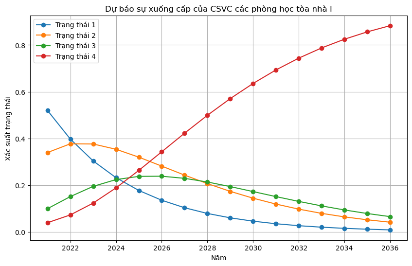

```
Bảng dự báo sự xuống cấp của CSVC (dạng số nguyên):
      Trạng thái 1  Trạng thái 2  Trạng thái 3  Trạng thái 4
2021            26            17             5             2
2022            20            19             7             4
2023            15            19            10             6
2024            12            18            11             9
2025             9            16            12            13
2026             7            14            12            17
2027             5            12            12            21
2028             4            10            11            25
2029             3             9            10            28
2030             2             7             9            32
2031             2             6             7            35
2032             1             5             7            37
2033             1             4             6            39
2034             1             3             5            41
2035             0             3             4            43
2036             1             2             3            44
```

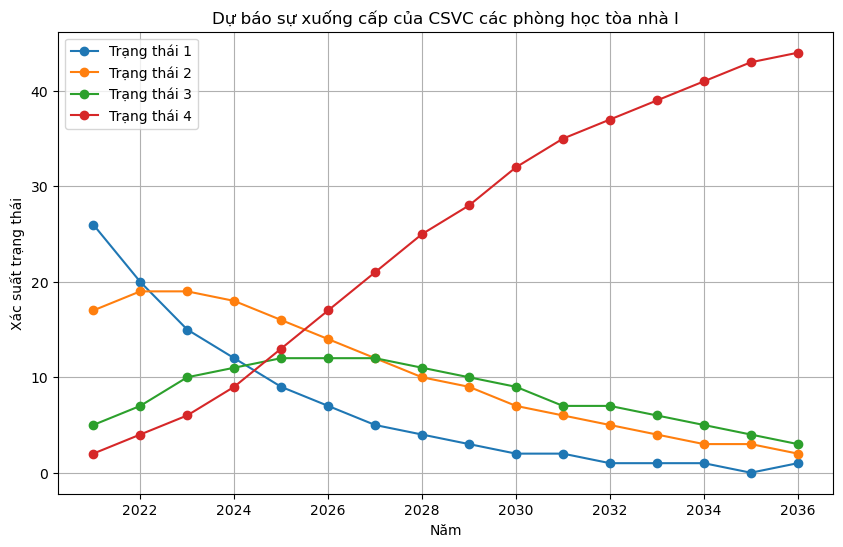

```python
def forecast_degradation(P: Matrix, pi_0: Matrix, years: int = 15) -> pd.DataFrame:
    """
    Dự báo sự xuống cấp của CSVC trong vòng 'years' năm tới.

    Args:
        P (Matrix): Ma trận chuyển trạng thái.
        pi_0 (Matrix): Vector phân phối xác suất ban đầu.
        years (int): Số năm để dự báo (mặc định là 15).

    Returns:
        pd.DataFrame: Bảng chứa phân phối xác suất cho từng năm.
    """
    forecast = []
    pi_t = pi_0
    for t in range(years + 1):  # Bao gồm năm hiện tại
        forecast.append([round(x[0], 4) for x in pi_t.data])
        pi_t = P * pi_t

    # Tạo DataFrame để hiển thị kết quả
    years_list = [init_year + i for i in range(years + 1)]
    df_forecast = pd.DataFrame(
        forecast, columns=[f"Trạng thái {i+1}" for i in range(P.rows)], index=years_list
    )

    return df_forecast


def forecast_degradation_integer(
    P: Matrix, pi_0: Matrix, total_rooms: int, years: int = 15
) -> pd.DataFrame:
    """
    Dự báo sự xuống cấp của CSVC trong vòng 'years' năm tới với dữ liệu ở dạng số nguyên.

    Args:
        P (Matrix): Ma trận chuyển trạng thái.
        pi_0 (Matrix): Vector phân phối xác suất ban đầu.
        total_rooms (int): Tổng số phòng học.
        years (int): Số năm để dự báo (mặc định là 15).

    Returns:
        pd.DataFrame: Bảng chứa phân phối xác suất cho từng năm dưới dạng số nguyên.
    """
    forecast = []
    pi_t = pi_0

    for t in range(years + 1):  # Bao gồm năm hiện tại
        # Nhân phân phối xác suất với tổng số phòng học để có số phòng dự đoán
        raw_forecast = [x[0] * total_rooms for x in pi_t.data]

        # Làm tròn xuống và tính phần dư
        rounded_forecast = [int(x) for x in raw_forecast]
        remainders = [x - r for x, r in zip(raw_forecast, rounded_forecast)]

        # Tính tổng sau khi làm tròn
        total_after_rounding = sum(rounded_forecast)

        # Phân bổ phần dư cho các trạng thái có phần dư lớn nhất
        while total_after_rounding < total_rooms:
            max_index = remainders.index(max(remainders))
            rounded_forecast[max_index] += 1
            remainders[max_index] = 0  # Đặt phần dư về 0 để không phân bổ thêm nữa
            total_after_rounding += 1

        forecast.append(rounded_forecast)
        pi_t = P * pi_t

    # Tạo DataFrame để hiển thị kết quả
    years_list = [init_year + i for i in range(years + 1)]
    df_forecast = pd.DataFrame(
        forecast, columns=[f"Trạng thái {i+1}" for i in range(P.rows)], index=years_list
    )

    return df_forecast


def plot_forecast(df_forecast: pd.DataFrame) -> None:
    """
    Vẽ biểu đồ dự báo sự xuống cấp của CSVC.

    Args:
        df_forecast (pd.DataFrame): DataFrame chứa kết quả dự báo.
    """
    df_forecast.plot(kind="line", figsize=(10, 6), marker="o")
    plt.title("Dự báo sự xuống cấp của CSVC các phòng học tòa nhà I")
    plt.xlabel("Năm")
    plt.ylabel("Xác suất trạng thái")
    plt.grid(True)
    plt.show()


# Sử dụng hàm để dự báo và vẽ biểu đồ
df_forecast_float = forecast_degradation(P, pi_0, years=15)
df_forecast_int = forecast_degradation_integer(P, pi_0, total_rooms, years=15)
print("\nBảng dự báo sự xuống cấp của CSVC (dạng xác suất):")
print(df_forecast_float)
plot_forecast(df_forecast_float)
print("\nBảng dự báo sự xuống cấp của CSVC (dạng số nguyên):")
print(df_forecast_int)
plot_forecast(df_forecast_int)
```

## 4.4. Xác định thời điểm (năm) phải phá hủy để xây lại/trùng tu tòa nhà I và tuổi thọ của tòa nhà I

**Chú thích:**: Trong hàm `find_rebuild_year` có tham số `precision` để xác định độ chính xác của kết quả (mặc định là 4). Thầy cô có thể tùy chỉnh giá trị của `precision` để kiểm tra kết quả với độ chính xác khác nhau.

```python
precision: int = 4


def find_rebuild_year(
    P: Matrix,
    pi_0: Matrix,
    total_rooms: int,
    init_year: int = 2021,
    precision: int = 4,
) -> int:
    """
    Xác định thời điểm cần phá hủy/trùng tu tòa nhà khi tất cả phòng học đều ở trạng thái xấu.

    Args:
        P (Matrix): Ma trận chuyển trạng thái.
        pi_0 (Matrix): Vector phân phối xác suất ban đầu.
        total_rooms (int): Tổng số phòng học.
        start_year (int): Năm bắt đầu theo dõi (mặc định là 2021).
        precision (int): Số chữ số thập phân để so sánh (mặc định là 4).

    Returns:
        int: Năm cần phá hủy/trùng tu.
    """
    pi_t = pi_0
    year = init_year
    while True:
        if (
            round(pi_t[-1][0] * total_rooms, ndigits=precision) == total_rooms
        ):  # Tất cả phòng học đều ở trạng thái 4
            return year
        pi_t = P * pi_t
        year += 1


# Sử dụng hàm để xác định năm cần phá hủy/trùng tu
rebuild_year = find_rebuild_year(
    P, pi_0, total_rooms, init_year=init_year, precision=precision
)
print(f"d. Năm cần phá hủy/trùng tu tòa nhà: {rebuild_year}")


def calculate_lifetime(rebuild_year: int, start_year: int = 2000) -> int:
    """
    Xác định tuổi thọ của tòa nhà I.

    Args:
        rebuild_year (int): Năm phá hủy/trùng tu.
        start_year (int): Năm bắt đầu theo dõi (mặc định là 2021).

    Returns:
        int: Tuổi thọ của tòa nhà I.
    """
    return rebuild_year - start_year


# Sử dụng hàm để xác định tuổi thọ của tòa nhà
lifetime = calculate_lifetime(rebuild_year, start_year=start_year)
print(f"e. Tuổi thọ của tòa nhà I: {lifetime} năm")
```

```
d. Năm cần phá hủy/trùng tu tòa nhà: 2084
e. Tuổi thọ của tòa nhà I: 84 năm
```

# 5. Kết luận

Trong bài toán này, em đã sử dụng xích Markov để mô hình hóa quá trình xuống cấp về CSVC của các phòng học thuộc tòa nhà I. Từ đó, em đã xây dựng ma trận chuyển trạng thái $P$ và vector phân phối xác suất ban đầu $\pi_0$, dự báo sự xuống cấp về CSVC của các phòng học trong vòng 15 năm tới, xác định thời điểm (năm) phải phá hủy để xây lại/trùng tu tòa nhà I và tuổi thọ của tòa nhà I. Kết quả dự báo và phân tích đã được trình bày ở phần 4. Thầy cô có thể kiểm tra kết quả bằng cách chạy các đoạn code ở phần 4.

# 6. Tài liệu tham khảo

- [1] [Pandas DataFrame](https://pandas.pydata.org/docs/reference/api/pandas.DataFrame.html)
- [2] [Matplotlib](https://matplotlib.org/stable/contents.html)